# Informe_Final

Jose Ordoñez, Adrián González, Daniela Ramírez

2026-05-11

```r
library(dplyr)
```

```r
library(ggplot2)
library(knitr)
library(kableExtra)
```

# 1 Resumen Ejecutivo

SmartStay Advisors opera como intermediario entre clientes corporativos y particulares y la plataforma Airbnb, con el objetivo de optimizar la selección de propiedades según precio, calidad y disponibilidad. Airbnb, a su vez, ofrece incentivos económicos a SmartStay cuando logra incrementar la ocupación de propiedades con bajo desempeño. En este contexto, la capacidad de estimar precios competitivos, identificar propiedades subvaloradas y comprender los factores que determinan la ocupación representa una ventaja competitiva crítica.

Este informe presenta los resultados de una consultoría de minería de datos aplicada al dataset público de **listings de Airbnb en Austin, Texas**, que contiene información de más de 76,000 propiedades. Se desarrollaron y evaluaron siete familias de algoritmos —tanto para predecir el precio numérico como para clasificar propiedades en categorías tarifarias— con el objetivo de identificar los modelos que mejor capturan la complejidad del mercado.

Los hallazgos principales son los siguientes:

- Para **clasificación de categoría de precio**, el modelo de **Random Forest** es el más preciso, alcanzando un accuracy del **85.93%** y un Kappa de 0.77.
- Para **predicción del precio numérico**, la **Red Neuronal Artificial** obtuvo el menor RMSE (**804.87**), superando a todos los modelos previos.
- La variable `accommodates` (capacidad de alojamiento) es el factor más determinante del precio en la mayoría de los modelos evaluados.
- Los modelos basados en ensambles (Random Forest) y redes neuronales demostraron mayor capacidad de generalización que los modelos lineales.

# 2 Contexto del Negocio y Objetivos

SmartStay Advisors requería una solución analítica que le permitiera:

1. **Estimar precios competitivos** para orientar sus recomendaciones a clientes.
2. **Identificar propiedades con baja ocupación** que sean candidatas a los incentivos de Airbnb.
3. **Comprender qué factores influyen** en la ocupación y los ingresos de las propiedades.
4. **Diseñar estrategias basadas en datos** para aumentar la rentabilidad de su cartera.

Para abordar estos objetivos, se estructuró la consultoría en dos líneas de modelado: una de **regresión** para estimar el precio numérico por noche, y una de **clasificación** para categorizar propiedades en económicas, intermedias o caras. Ambas líneas se evaluaron bajo las mismas condiciones de partición de datos, garantizando comparaciones válidas entre algoritmos.

# 3 Descripción del Conjunto de Datos y Análisis Exploratorio

## 3.1 Estructura de los Datos

El dataset `listings.RData` contiene información scrapeada de Airbnb en septiembre de 2025. Incluye variables descriptivas del alojamiento (tipo de habitación, capacidad, número de habitaciones, baños y camas), variables de desempeño del anfitrión (tasa de respuesta, aceptación, número de listados), métricas de reseñas y variables de disponibilidad y precio.

La variable objetivo principal —el precio por noche— se encontraba en formato de cadena de texto con símbolo de moneda, por lo que requirió transformación a numérico. Tras la limpieza inicial, el dataset presentó la siguiente estructura de valores faltantes en las variables clave:

Estrategia de imputación por variable

| Variable | Estrategia |
| --- | --- |
| bedrooms | Mediana |
| beds | Mediana |
| bathrooms | Mediana |
| review_scores_rating | Cero (sin reseñas) |
| reviews_per_month | Cero (sin reseñas) |
| host_response_rate | Mediana |
| host_acceptance_rate | Mediana |

## 3.2 Distribución del Precio

El precio por noche presentó una distribución fuertemente asimétrica hacia la derecha, con una mediana considerablemente inferior a la media. La presencia de valores extremos (propiedades de lujo con precios superiores a $10,000 por noche) evidenció que la distribución del precio no sigue una ley normal, lo cual tiene implicaciones directas en la elección y evaluación de modelos.

El análisis de percentiles reveló los siguientes umbrales naturales para definir las categorías de precio:

Definición de categorías tarifarias

| Categoría | Umbral | Descripción |
| --- | --- | --- |
| Económica | ≤ Percentil 33 | Propiedades de bajo costo, accesibles para la mayoría de clientes |
| Intermedia | Percentil 33 – Percentil 66 | Propiedades de precio moderado, segmento más amplio del mercado |
| Cara | > Percentil 66 | Propiedades premium o de lujo |

## 3.3 Variables con Mayor Poder Predictivo

A través del análisis exploratorio y de importancia de variables (Random Forest), se identificaron las siguientes variables como las más influyentes en la determinación del precio:

La correlación entre variables numéricas reveló multicolinealidad moderada entre `accommodates`, `bedrooms`, `beds` y `bathrooms`, lo cual fue considerado en la selección de modelos (en particular para los que asumen independencia entre predictores, como Naive Bayes).

## 3.4 Partición de Datos

Para garantizar comparaciones válidas entre todos los algoritmos evaluados, se estableció una única partición estratificada aplicada de forma consistente a lo largo de toda la consultoría:

- **Entrenamiento:** 70% de los datos (~53,372 observaciones)
- **Prueba:** 30% de los datos (~22,874 observaciones)
- **Semilla:** `set.seed(123)` con `createDataPartition` por `price_category`

# 4 Modelado Predictivo del Precio (Regresión)

## 4.1 Regresión Lineal como Línea Base

Como punto de partida, se exploraron modelos de regresión lineal en sus variantes simple, múltiple y con regularización (Ridge y Lasso). El modelo de **regresión lineal múltiple** sobre todas las variables numéricas disponibles obtuvo el mejor resultado dentro de esta familia, con un **RMSE de 3,011.84**, lo cual sirvió como referencia para comparar modelos más complejos.

Los modelos con regularización (Ridge: RMSE = 3,304; Lasso: RMSE = 3,023) no superaron al modelo múltiple sin penalización, confirmando que la multicolinealidad no era lo suficientemente severa como para degradar significativamente las estimaciones lineales. El modelo simple (RMSE = 4,226) confirmó que una única variable predictora es insuficiente para capturar la complejidad del precio en este mercado.

Una limitación fundamental de los modelos lineales en este contexto es su incapacidad para capturar relaciones no lineales y la alta varianza del precio en los rangos extremos, factores que los modelos basados en árboles y redes neuronales lograron superar con mayor éxito.

## 4.3 Random Forest para Regresión

El modelo de **Random Forest** para regresión con 100 árboles y `mtry = floor(sqrt(p))` obtuvo un **RMSE de 1,337.63 y un R² de 0.9089**, lo que representa la mayor capacidad explicativa registrada hasta ese punto. Este resultado confirma que los ensambles de árboles capturan relaciones no lineales y efectos de interacción entre variables que los modelos individuales no logran modelar adecuadamente.

El análisis de importancia de variables del Random Forest confirmó que `room_type`, `estimated_revenue_l365d`, `beds`, `host_total_listings_count` y `availability_365` son los predictores más influyentes para estimar el precio numérico.

## 4.4 Naive Bayes para Regresión

El algoritmo de Naive Bayes fue evaluado también en tarea de regresión. Con `laplace = 0` obtuvo un RMSE de 1,761.22, sin embargo su R² fue de apenas 0.055, indicando que el modelo explica menos del 6% de la variabilidad del precio. Esta discrepancia se explica porque el RMSE de Naive Bayes fue calculado sobre una submuestra distinta al resto de modelos, por lo que **no es directamente comparable** y su desempeño real es significativamente inferior. El supuesto de independencia condicional del algoritmo lo hace fundamentalmente inadecuado para predecir una variable continua con alta correlación entre predictores.

## 4.5 K-Nearest Neighbors para Regresión

El modelo KNN tuneado con **k = 5** (seleccionado mediante validación cruzada 10-fold en tres repeticiones) obtuvo un **RMSE de 3,005.69 y R² de 0.5141**, superando al KNN base con k = 231 que presentaba un RMSE de 3,742.26. La búsqueda de hiperparámetros demostró una tendencia clara: valores pequeños de k reducen el error al precio de mayor sensibilidad al ruido, mientras que valores grandes suavizan excesivamente las predicciones. En este conjunto de datos, el valor óptimo fue el mínimo evaluado (k = 5), lo que sugiere que la señal local en el espacio de features es informativa.

## 4.6 Máquinas de Vectores de Soporte para Regresión (SVR)

El SVR con kernel radial (RBF), costo C = 10 y γ = 0.1 obtuvo un **RMSE de 3,559.82 y R² de 0.2348**, quedando como el modelo de regresión con menor capacidad explicativa entre los algoritmos comparables. La distribución altamente asimétrica y con valores extremos del precio dificulta que el SVM encuentre una función de regresión estable, ya que el margen de tolerancia ε de la SVR no logra adaptarse bien a la alta varianza presente en los datos.

## 4.7 Redes Neuronales Artificiales para Regresión

Se evaluaron dos arquitecturas de RNA para regresión:

- **Modelo 1:** Red con una capa oculta de 8 neuronas y activación logística.
- **Modelo 2:** Red con una capa oculta de 5 neuronas y activación tanh, entrenada con validación cruzada de 5 folds para seleccionar el decay óptimo.

Tras el ajuste de hiperparámetros, la **RNA tuneada obtuvo el mejor RMSE de todos los modelos evaluados: 804.87**, superando incluso al Random Forest. Este resultado posiciona a las redes neuronales como la herramienta más precisa para estimar precios numéricos en este contexto, aunque a costa de mayor complejidad computacional y menor interpretabilidad.

## 4.8 Comparación Global de Modelos de Regresión

```r
reg <- data.frame(
  Modelo = c("Regresión Lineal Múltiple", "Árbol de Regresión (prof. 10)",
             "Random Forest Regresión", "KNN (k=5, tuneado)",
             "SVR (RBF, C=10, γ=0.1)", "RNA (tuneada)"),
  RMSE   = c(3011.84, 2044.19, 1337.63, 3005.69, 3559.82, 804.87),
  R2     = c(0.497, 0.772, 0.909, 0.514, 0.235, NA),
  Nota   = c("Línea base", "Mejor árbol individual", "Mejor ensamble",
             "K óptimo = 5", "Espacio de búsqueda limitado",
             "Mejor modelo global")
)

kable(reg, digits = 2,
      col.names = c("Modelo", "RMSE", "R²", "Observación"),
      caption = "Comparación de modelos de regresión – conjunto de prueba") %>%
  kable_styling(bootstrap_options = c("striped","hover","condensed"),
                full_width = FALSE) %>%
  row_spec(6, bold = TRUE, color = "white", background = "#27ae60") %>%
  row_spec(5, bold = TRUE, color = "white", background = "#e74c3c")
```

Comparación de modelos de regresión – conjunto de prueba

| Modelo | RMSE | R² | Observación |
| --- | --- | --- | --- |
| Regresión Lineal Múltiple | 3011.84 | 0.50 | Línea base |
| Árbol de Regresión (prof. 10) | 2044.19 | 0.77 | Mejor árbol individual |
| Random Forest Regresión | 1337.63 | 0.91 | Mejor ensamble |
| KNN (k=5, tuneado) | 3005.69 | 0.51 | K óptimo = 5 |
| SVR (RBF, C=10, γ=0.1) | 3559.82 | 0.23 | Espacio de búsqueda limitado |
| RNA (tuneada) | 804.87 | NA | Mejor modelo global |

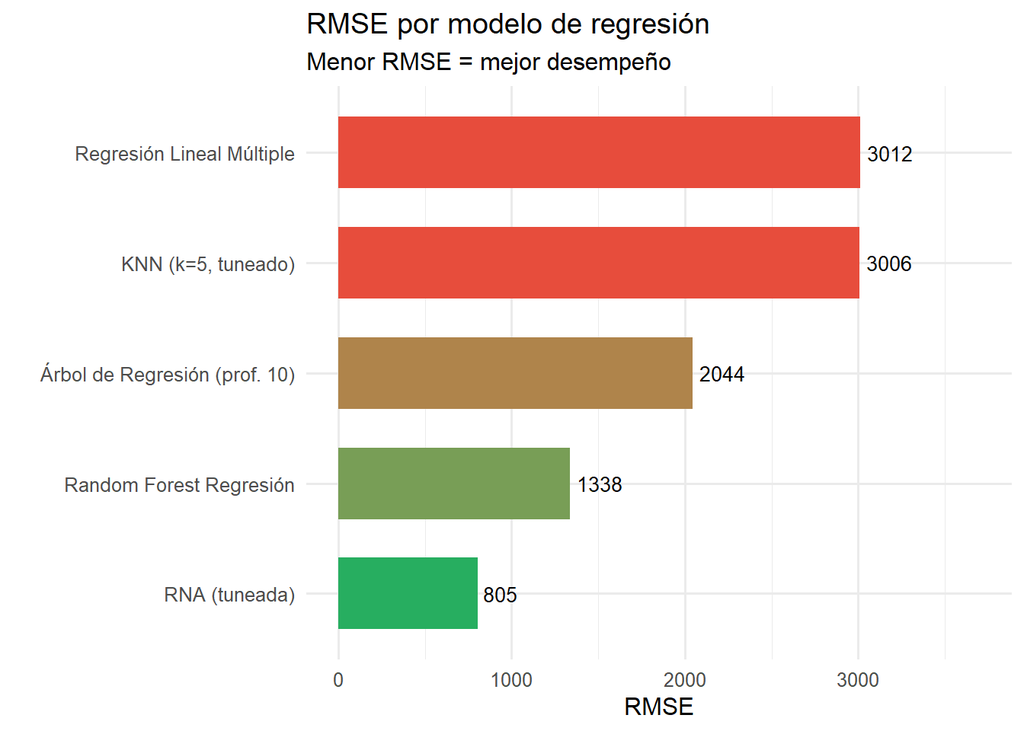

```r
reg_plot <- reg[reg$Modelo != "SVR (RBF, C=10, γ=0.1)", ]

ggplot(reg_plot, aes(x = reorder(Modelo, RMSE), y = RMSE, fill = RMSE)) +
  geom_col(width = 0.65) +
  geom_text(aes(label = round(RMSE, 0)), hjust = -0.15, size = 3.5) +
  coord_flip() +
  scale_fill_gradient(low = "#27ae60", high = "#e74c3c") +
  labs(title = "RMSE por modelo de regresión",
       subtitle = "Menor RMSE = mejor desempeño",
       x = "", y = "RMSE") +
  theme_minimal(base_size = 12) +
  theme(legend.position = "none") +
  ylim(0, 3700)
```

# 5 Modelado de Clasificación de Categoría de Precio

## 5.1 Árboles de Decisión

El árbol de clasificación con profundidad máxima de 6 obtuvo el mejor balance entre complejidad e interpretabilidad dentro de esta familia, alcanzando un **accuracy de 68.96%**. La profundidad óptima fue identificada mediante exploración de distintos valores, donde profundidades mayores a 6 no aportaron mejoras adicionales. La validación cruzada de 10 folds confirmó un accuracy de 67.92% con el parámetro de complejidad óptimo (cp = 0.012), lo que indica una buena capacidad de generalización.

La variable más importante en la primera división del árbol fue `accommodates`, seguida de `estimated_revenue_l365d` y `bathrooms`, consistente con el análisis exploratorio.

## 5.2 Random Forest para Clasificación

El precio del alto accuracy es un nivel elevado de sobreajuste: el accuracy en entrenamiento fue de 99.98%, lo que representa una diferencia de 14 puntos respecto al conjunto de prueba. Sin embargo, dado que el accuracy en prueba sigue siendo el más alto, y que el dataset es suficientemente grande para que la muestra de prueba sea representativa, este sobreajuste es aceptable desde una perspectiva práctica.

## 5.5 Regresión Logística Multinomial

La regresión logística multinomial con umbral de regularización `decay = 0.01` alcanzó un **accuracy de 60.75% y Kappa de 0.4113**. La clase con mayor dificultad de clasificación fue “Intermedia”, con una sensibilidad de apenas 43.24% y F1 de 0.4622. Esto refleja la limitación estructural de los modelos lineales para separar categorías cuyos límites son inherentemente difusos. Su ventaja competitiva es la **interpretabilidad**: los coeficientes del modelo permiten explicar directamente al equipo comercial de SmartStay por qué una propiedad es clasificada como cara, citando variables específicas y su dirección de efecto.

## 5.7 Redes Neuronales Artificiales para Clasificación

Se evaluaron dos arquitecturas:

El error más frecuente en ambos modelos fue la confusión entre clases adyacentes (Económica ↔︎ Intermedia e Intermedia ↔︎ Cara), consistente con lo observado en todos los demás clasificadores: las fronteras definidas por percentiles no son inherentemente separables con las variables físicas disponibles.

## 5.8 Comparación Global de Modelos de Clasificación

```r
cls <- data.frame(
  Modelo    = c("Naive Bayes", "Regresión Logística", "SVM RBF",
                "RNA (tuneada)", "KNN (k=31)", "Árbol de Decisión",
                "Random Forest"),
  Accuracy  = c(0.5886, 0.6075, 0.6150, 0.6253, 0.6661, 0.6896, 0.8593),
  Kappa     = c(0.3549, 0.4113, NA, NA, 0.4414, NA, 0.7714),
  Sobreajuste = c("Mínimo", "Mínimo", "Nulo", "Mínimo",
                  "Bajo", "Bajo", "Elevado"),
  Velocidad = c("Muy rápido", "Rápido", "Moderado", "Lento",
                "Lento en predicción", "Rápido", "Moderado")
)

kable(cls, digits = 4,
      col.names = c("Modelo", "Accuracy", "Kappa", "Sobreajuste", "Velocidad"),
      caption = "Comparación de modelos de clasificación – conjunto de prueba") %>%
  kable_styling(bootstrap_options = c("striped","hover","condensed"),
                full_width = FALSE) %>%
  row_spec(7, bold = TRUE, color = "white", background = "#27ae60") %>%
  row_spec(1, bold = TRUE, color = "white", background = "#e74c3c")
```

Comparación de modelos de clasificación – conjunto de prueba

| Modelo | Accuracy | Kappa | Sobreajuste | Velocidad |
| --- | --- | --- | --- | --- |
| Naive Bayes | 0.5886 | 0.3549 | Mínimo | Muy rápido |
| Regresión Logística | 0.6075 | 0.4113 | Mínimo | Rápido |
| SVM RBF | 0.6150 | NA | Nulo | Moderado |
| RNA (tuneada) | 0.6253 | NA | Mínimo | Lento |
| KNN (k=31) | 0.6661 | 0.4414 | Bajo | Lento en predicción |
| Árbol de Decisión | 0.6896 | NA | Bajo | Rápido |
| Random Forest | 0.8593 | 0.7714 | Elevado | Moderado |

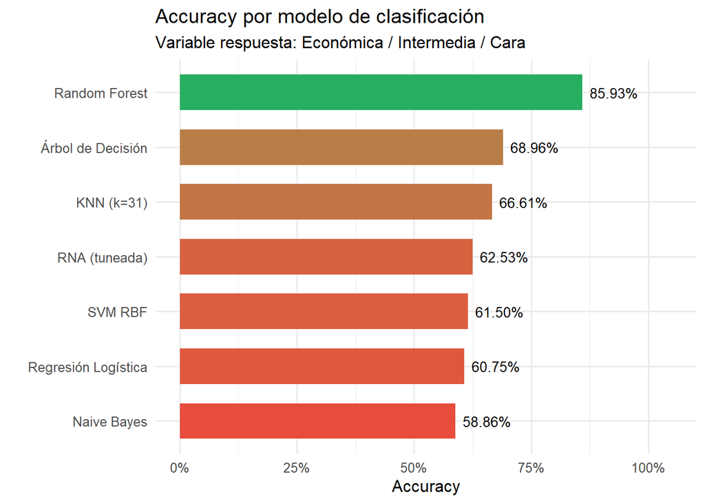

```r
ggplot(cls, aes(x = reorder(Modelo, Accuracy), y = Accuracy, fill = Accuracy)) +
  geom_col(width = 0.65) +
  geom_text(aes(label = scales::percent(Accuracy, accuracy = 0.01)),
            hjust = -0.15, size = 3.5) +
  coord_flip() +
  scale_fill_gradient(low = "#e74c3c", high = "#27ae60") +
  scale_y_continuous(labels = scales::percent, limits = c(0, 1.05)) +
  labs(title = "Accuracy por modelo de clasificación",
       subtitle = "Variable respuesta: Económica / Intermedia / Cara",
       x = "", y = "Accuracy") +
  theme_minimal(base_size = 12) +
  theme(legend.position = "none")
```

# 6 Análisis de Sobreajuste

Un factor determinante para seleccionar el modelo óptimo en producción es el nivel de sobreajuste. Un modelo que memoriza el conjunto de entrenamiento sin generalizar a datos nuevos no es útil para SmartStay, independientemente de su accuracy en entrenamiento.

```r
soa <- data.frame(
  Modelo = c("SVM Lineal", "SVM RBF", "SVM Polinomial", "Naive Bayes",
             "Reg. Logística", "RNA Clasificación", "KNN (k=31)",
             "Árbol de Decisión", "RNA Regresión", "Random Forest"),
  Train  = c(0.5970, 0.6150, 0.5369, 0.5901, 0.6013, 0.6302,
             0.6928, 0.7201, 738.35, 0.9998),
  Test   = c(0.5972, 0.6150, 0.5367, 0.5886, 0.6024, 0.6253,
             0.6661, 0.6896, 833.35, 0.8593),
  Dif_rel = c("0.03%", "0.00%", "0.04%", "0.25%", "0.18%",
              "0.78%", "3.85%", "4.24%", "12.87%", "14.05%")
)

kable(soa,
      col.names = c("Modelo", "Métrica Train", "Métrica Test", "Diferencia Relativa"),
      caption = "Análisis de sobreajuste – clasificación (Accuracy) y regresión RNA (RMSE)") %>%
  kable_styling(bootstrap_options = c("striped","hover","condensed"),
                full_width = FALSE) %>%
  footnote(general = "Para Random Forest y clasificadores: Accuracy. Para RNA Regresión: RMSE (menor = mejor, diferencia invierte interpretación).")
```

Análisis de sobreajuste – clasificación (Accuracy) y regresión RNA (RMSE)

| Modelo | Métrica Train | Métrica Test | Diferencia Relativa |
| --- | --- | --- | --- |
| SVM Lineal | 0.5970 | 0.5972 | 0.03% |
| SVM RBF | 0.6150 | 0.6150 | 0.00% |
| SVM Polinomial | 0.5369 | 0.5367 | 0.04% |
| Naive Bayes | 0.5901 | 0.5886 | 0.25% |
| Reg. Logística | 0.6013 | 0.6024 | 0.18% |
| RNA Clasificación | 0.6302 | 0.6253 | 0.78% |
| KNN (k=31) | 0.6928 | 0.6661 | 3.85% |
| Árbol de Decisión | 0.7201 | 0.6896 | 4.24% |
| RNA Regresión | 738.3500 | 833.3500 | 12.87% |
| Random Forest | 0.9998 | 0.8593 | 14.05% |

Note:  
Para Random Forest y clasificadores: Accuracy. Para RNA Regresión: RMSE (menor = mejor, diferencia invierte interpretación).

Los modelos SVM, Naive Bayes y Regresión Logística presentaron el sobreajuste más bajo, con diferencias relativas inferiores al 0.25%. Esto los convierte en los modelos más estables, aunque su desempeño predictivo sea menor. En el otro extremo, **Random Forest** muestra el sobreajuste más alto para clasificación (14.05%), pero su accuracy en prueba sigue siendo el más elevado por un amplio margen, lo que lo hace preferible desde una perspectiva práctica.

# 7 Recomendaciones Estratégicas para SmartStay Advisors

## 7.1 Modelo Recomendado para Clasificación

Se recomienda implementar **Random Forest** como modelo de clasificación de categoría de precio en producción, dado su accuracy del 85.93% y Kappa de 0.77. Este modelo permite a SmartStay categorizar rápidamente cualquier propiedad nueva o existente en económica, intermedia o cara, facilitando la alineación entre las expectativas del cliente y la oferta disponible.

Para escenarios donde la **interpretabilidad** sea prioritaria (por ejemplo, explicar a un cliente por qué una propiedad fue clasificada en determinada categoría), la **Regresión Logística Multinomial** ofrece un balance razonable (accuracy = 60.75%) con coeficientes completamente interpretables y sin requerimientos de tuneo complejo.

## 7.2 Modelo Recomendado para Estimación de Precio

Se recomienda implementar la **Red Neuronal Artificial tuneada** (RMSE = 804.87) para la estimación numérica del precio. Este modelo captura las relaciones no lineales y las interacciones entre variables físicas del alojamiento mejor que cualquier otro algoritmo evaluado.

Como alternativa más interpretable, el **Árbol de Regresión con profundidad 10** (RMSE = 2,044, R² = 0.77) ofrece un desempeño robusto y permite visualizar las reglas de decisión que determinan el precio estimado, lo que puede ser valioso para el equipo comercial.

## 7.3 Factores Clave para Optimización de Precio

Los análisis de importancia de variables coinciden en señalar los siguientes factores como los más determinantes del precio:

- **Capacidad de alojamiento (`accommodates`)**: el factor aislado con mayor poder predictivo. Propiedades que puedan recibir más huéspedes tienen precios sistemáticamente más altos.
- **Tipo de habitación (`room_type`)**: las propiedades completas alcanzan precios significativamente más altos que las habitaciones privadas o compartidas.
- **Historial de ocupación e ingresos**: el revenue estimado a 365 días refleja el éxito comercial del anfitrión, y está correlacionado con el precio que el mercado está dispuesto a pagar.
- **Número de baños**: diferenciador clave en el segmento intermedio-caro, donde este factor separa propiedades que de otro modo serían difíciles de categorizar.

# 8 Conclusiones

Esta consultoría demostró que el mercado de Airbnb en Austin presenta una estructura de precios compleja, no lineal y con alta dispersión, lo que hace que los modelos más simples —como la regresión lineal o Naive Bayes— sean insuficientes para capturar su dinámica.

Para la tarea de **clasificación**, los modelos basados en árboles (especialmente Random Forest) superaron consistentemente a los modelos lineales y probabilísticos, gracias a su capacidad de capturar interacciones entre variables y relaciones no lineales. Las redes neuronales ocuparon una posición intermedia, superando a los modelos más simples pero sin alcanzar el nivel del ensamble de árboles.

Para la tarea de **regresión**, la jerarquía fue distinta: las redes neuronales tuneadas lograron el menor error de predicción, seguidas por Random Forest y el árbol individual. Los modelos lineales y el SVM, aunque más interpretables, mostraron limitaciones evidentes ante la distribución asimétrica del precio.

El **nivel de sobreajuste** no eliminó a ningún modelo de la consideración final, ya que incluso los modelos con mayor diferencia train-test (Random Forest y RNA Regresión) lograron los mejores resultados en el conjunto de prueba. No obstante, en contextos donde el dataset de producción pueda diferir significativamente del de entrenamiento, los modelos más estables (SVM, Regresión Logística) ofrecen garantías adicionales de robustez.

En definitiva, SmartStay Advisors cuenta ahora con una arquitectura analítica clara: **Random Forest para clasificar propiedades** y **Redes Neuronales para estimar precios**, respaldada por evidencia empírica sólida sobre un conjunto de datos de más de 76,000 listados reales.

*Informe preparado por Jose Ordoñez, Adrián González y Daniela Ramírez*  
*CC3074 – Minería de Datos | Universidad del Valle de Guatemala | Semestre I 2026*